# Project 2

##### For Project 2 I will be testing a data set I created in a previous computer science class. I gathered this information from Pokemon website and extracted the information into a csv file on Excel. After cleaning and removing less relevant data and unecessary characters I was still left with a few NAs but I will be removing them here in R leaving plenty of data to use. My dataset is information about all Pokemon that have been released up to ~2020.

```r
library(tidyr)
library(readr)
library(mosaic)
library(yarrr)
```

```r
poke <- Pokemon %>% na.omit()
poke
```

| # | Name | Type 1 | Type 2 | Total | HP | Attack | Defense | Sp. Atk | Sp. Def | Speed | Generation | Legendary |
| --- | --- | --- | --- | --- | --- | --- | --- | --- | --- | --- | --- | --- |
| 1 | Bulbasaur | Grass | Poison | 318 | 45 | 49 | 49 | 65 | 65 | 45 | 1 | FALSE |
| 2 | Ivysaur | Grass | Poison | 405 | 60 | 62 | 63 | 80 | 80 | 60 | 1 | FALSE |
| 3 | Venusaur | Grass | Poison | 525 | 80 | 82 | 83 | 100 | 100 | 80 | 1 | FALSE |
| 3 | VenusaurMega Venusaur | Grass | Poison | 625 | 80 | 100 | 123 | 122 | 120 | 80 | 1 | FALSE |
| 6 | Charizard | Fire | Flying | 534 | 78 | 84 | 78 | 109 | 85 | 100 | 1 | FALSE |
| 6 | CharizardMega Charizard X | Fire | Dragon | 634 | 78 | 130 | 111 | 130 | 85 | 100 | 1 | FALSE |
| 6 | CharizardMega Charizard Y | Fire | Flying | 634 | 78 | 104 | 78 | 159 | 115 | 100 | 1 | FALSE |
| 12 | Butterfree | Bug | Flying | 395 | 60 | 45 | 50 | 90 | 80 | 70 | 1 | FALSE |
| 13 | Weedle | Bug | Poison | 195 | 40 | 35 | 30 | 20 | 20 | 50 | 1 | FALSE |
| 14 | Kakuna | Bug | Poison | 205 | 45 | 25 | 50 | 25 | 25 | 35 | 1 | FALSE |

[output cut: 404 more lines]

*I would like to observe the two quantitative columns: HP and Attack. HP (response variable) describes the health points that each named Pokemon start at and Attack (explanatory variable) is there according attack power. I find it very interesting that from the looks of our plots there is somewhat of a linear relationship that may be happening here!*

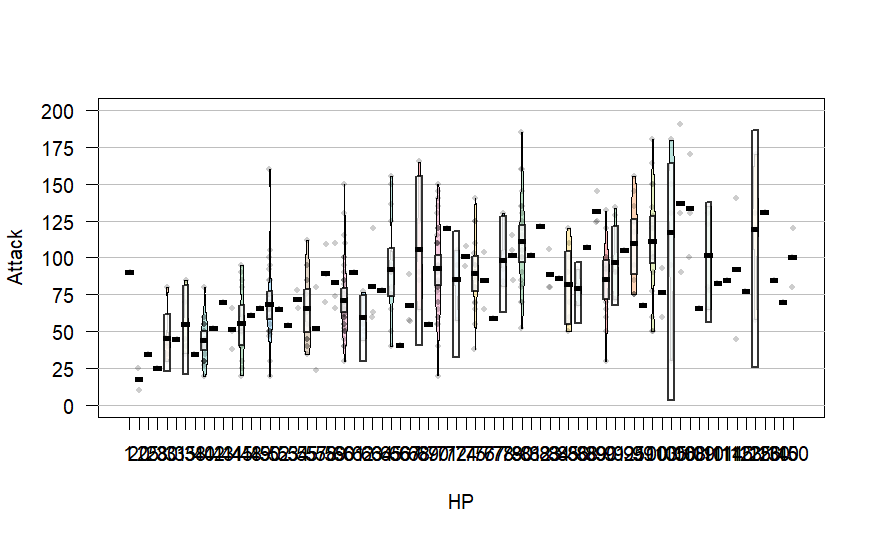

```r
pirateplot(Attack ~ HP, data = poke)
```

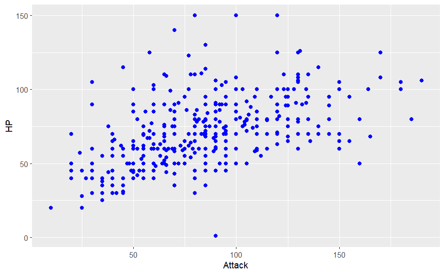

```r
ggplot() + geom_point( mapping = aes(x = Attack, y = HP ), data = poke, color = 'blue', size = 2 )
```

The four Assumptions for Linear Regression